# Análisis Exploratorio

Flavio Galán, Gustavo Cruz, Pedro Guzmán

2025-03-26

# Análisis Exploratorio

## Obtención y limpieza del Dataset

Los datos con los que trabajaremos serán los de INE, específicamente los datos relacionado a violencia intrafamiliar.

Primero tenemos que unir todos los datos recopilados desde el 2013 hasta el 2023, para lograrlo nos topamos con varias dificultades, la primera de esta es que los datos no tienen la misma cantidad de columnas en todos los años como se puede apreciar a continuación.

```
##                 column_name data_2013 data_2014 data_2015 data_2016 data_2017
## 1                 AGR_ALFAB   numeric   numeric   numeric   numeric   numeric
## 2                AGR_DEDICA   numeric   numeric   numeric   numeric   numeric
## 3                  AGR_EDAD   numeric   numeric   numeric   numeric   numeric
## 4           AGR_ESCOLARIDAD   numeric   numeric   numeric   numeric   numeric
## 5               AGR_EST_CIV   numeric   numeric   numeric   numeric   numeric
## 6                AGR_GURPET   numeric   numeric   numeric   numeric   numeric
## 7              AGR_NACIONAL   numeric   numeric   numeric   numeric   numeric
## 8                  AGR_OCUP   numeric   numeric   numeric   numeric   numeric
## 9             AGR_OTRAS_MUJ   numeric   numeric   numeric   numeric   numeric
## 10           AGR_OTRAS_N_AS   numeric   numeric   numeric   numeric   numeric
## 11            AGR_OTROS_HOM   numeric   numeric   numeric   numeric   numeric
## 12           AGR_OTROS_N_OS   numeric   numeric   numeric   numeric   numeric
## 13                 AGR_SEXO   numeric   numeric   numeric   numeric   numeric
## 14              AGR_TRABAJA   numeric   numeric   numeric   numeric   numeric
```

[output cut: 139 more lines]

Sin embargo se logró encontrar un patrón, todos los datasets realmente solo agregan variables al original del 2013, por lo tanto se ignoró todas las variables “extras” no incluidas dentro del dataset del 2013 y se unieron todos los datasets:

```
##     HEC_DIA         HEC_MES         HEC_ANO       HEC_DEPTO
##  Min.   : 1.00   Min.   : 1.00   Min.   :2000   Min.   : 1.0
##  1st Qu.: 7.00   1st Qu.: 3.00   1st Qu.:2015   1st Qu.: 1.0
##  Median :15.00   Median : 6.00   Median :2018   Median :10.0
##  Mean   :15.33   Mean   : 6.19   Mean   :2018   Mean   : 8.9
##  3rd Qu.:23.00   3rd Qu.:10.00   3rd Qu.:2021   3rd Qu.:16.0
##  Max.   :31.00   Max.   :12.00   Max.   :2023   Max.   :22.0
##  NA's   :16084   NA's   :33585   NA's   :4170   NA's   :330334
##  HEC_DEPTOMCPIO    HEC_TIPAGRE   NUMERO_BOLETA     DIA_EMISION
##  Min.   : 101.0   Min.   :1111   Min.   :    0    Min.   : 1.00
##  1st Qu.: 311.0   1st Qu.:1122   1st Qu.:   40    1st Qu.: 8.00
##  Median :1003.0   Median :1222   Median :   95    Median :15.00
##  Mean   : 961.3   Mean   :1603   Mean   : 1057    Mean   :15.32
##  3rd Qu.:1601.0   3rd Qu.:2122   3rd Qu.:  363    3rd Qu.:23.00
##  Max.   :2217.0   Max.   :2221   Max.   :17020    Max.   :31.00
##  NA's   :1859                    NA's   :254152
##   MES_EMISION      ANO_EMISION       DEPTO         DEPTO_MCPIO
##  Min.   : 1.000   Min.   :2013   Min.   : 1.0     Min.   : 101.0
##  1st Qu.: 4.000   1st Qu.:2015   1st Qu.: 1.0     1st Qu.: 309.0
##  Median : 6.000   Median :2018   Median : 9.0     Median :1003.0
##  Mean   : 6.421   Mean   :2018   Mean   : 8.7     Mean   : 958.3
##  3rd Qu.: 9.000   3rd Qu.:2021   3rd Qu.:15.0     3rd Qu.:1601.0
##  Max.   :12.000   Max.   :2023   Max.   :22.0     Max.   :2217.0
##                                  NA's   :327781
##  QUIEN_REPORTA      VIC_SEXO        VIC_EDAD      TOTAL_HIJOS
##  Min.   :1.000   Min.   :1.000   Min.   : 1.00   Min.   : 0.00
##  1st Qu.:1.000   1st Qu.:2.000   1st Qu.:24.00   1st Qu.: 1.00
##  Median :1.000   Median :2.000   Median :31.00   Median : 2.00
##  Mean   :1.031   Mean   :1.878   Mean   :33.63   Mean   : 2.08
##  3rd Qu.:1.000   3rd Qu.:2.000   3rd Qu.:40.00   3rd Qu.: 3.00
##  Max.   :3.000   Max.   :2.000   Max.   :98.00   Max.   :19.00
##  NA's   :4362                    NA's   :5635    NA's   :75236
##   NUM_HIJ_HOM     NUM_HIJ_MUJ      VIC_ALFAB     VIC_ESCOLARIDAD
##  Min.   : 0.00   Min.   : 0.00   Min.   :1.000   Min.   :10.0
##  1st Qu.: 0.00   1st Qu.: 0.00   1st Qu.:1.000   1st Qu.:23.0
##  Median : 1.00   Median : 1.00   Median :1.000   Median :29.0
##  Mean   : 1.08   Mean   : 1.01   Mean   :1.163   Mean   :29.7
##  3rd Qu.: 2.00   3rd Qu.: 2.00   3rd Qu.:1.000   3rd Qu.:39.0
##  Max.   :14.00   Max.   :14.00   Max.   :2.000   Max.   :59.0
##  NA's   :74409   NA's   :74364   NA's   :3326    NA's   :12268
```

[output cut: 97 more lines]

```
##  Min.   :141.0    Min.   :  0.0    Min.   :0        Min.   :0
##  1st Qu.:141.0    1st Qu.:142.0    1st Qu.:0        1st Qu.:0
##  Median :141.0    Median :142.0    Median :0        Median :0
##  Mean   :147.4    Mean   :113.6    Mean   :0        Mean   :0
##  3rd Qu.:141.0    3rd Qu.:142.0    3rd Qu.:0        3rd Qu.:0
##  Max.   :173.0    Max.   :142.0    Max.   :0        Max.   :0
##  NA's   :365124   NA's   :365124   NA's   :365124   NA's   :365124
##  MEDIDAS_SEGURIDAD TIPO_MEDIDA        ORGANISMO_REMITE
##  Min.   :1         Length:365129      Min.   : 1.00
##  1st Qu.:1         Class :character   1st Qu.:17.00
##  Median :1         Mode  :character   Median :17.00
##  Mean   :1                            Mean   :15.71
##  3rd Qu.:1                            3rd Qu.:18.00
##  Max.   :2                            Max.   :19.00
##  NA's   :171957                       NA's   :277781
```

Con esto podemos decir que el dataset tiene 75 variables y 365129 observaciones.

Finalmente tenemos un dataset con las siguiente variables:

- ANO_EMISION: Representa el año de emisión de la denuncia. (Cuantitativa Discreta)
- MES_EMISION: Representa el mes de emisión o registro de la denuncia. (Cuantitativa Discreta)
- DIA_EMISION: Representa el día de emisión o registro de la denuncia. (Cuantitativa Discreta)
- HEC_DEPTO: Departamento de Registro (Cualitativa Nominal).
- DEPTO_MUNICIPIO: Representa la unión del número del departamento y del municipio. (Cualitativa Nominal).
- QUIEN_REPORTA: Persona que reporta el hecho. (Cualitativa Nominal)
- VIC_SEXO: Sexo de la víctima. (Cualitativa Nominal)
- VIC_EDAD: Edad de la víctima. (Cuantitativa Discreta)
- TOTAL_HIJOS: Cantidad de hijos de la víctima. (Cuantitativa Discreta)
- NUM_HIJ_HOM: Número de hijos hombres de la víctima. (Cuantitativa Discreta).
- NUM_HIJ_MUJ: Número de hijas mujeres de la víctima. (Cuantitativa Discreta).
- VIC_ALFAB: Si la víctima sabe leer o escribir. (Cualitativa nominal)
- VIC_ESCOLARIDAD: Nivel de escolaridad de la víctima. (Cualitativa jerárquica)
- VIC_EST_CIV: Estado civil de la víctima. (Cualitativa Nominal)
- VIC_GRUPET: Pueblo de pertenencia de la víctima. (Cualitativa Nominal)
- VIC_NACIONAL: Nacionalidad de la víctima. (Cualitativa Nominal)
- VIC_TRABAJA: Condición de empleo de la víctima. (Cualitativa Nominal)
- VIC_OCUP: Ocupación de la víctima. (Cualitativa Nominal)
- VIC_DEDICA: A qué se dedica la víctima. (Cualitativa Nominal)
- VIC_DISC: Discapacidad de la víctima. (Cualitativa Nominal)
- TIPO_DISCAQ: Tipo de discapacidad de la víctima. (Cualitativa Nominal).
- VIC_REL_AGR: Relación de la víctima con el agresor. (Cualitativa Nominal).
- OTRAS_VICTIMAS: Total de otras víctimas. (Cuantitativa Discreta).
- VIC_OTRAS_HOM: Otras víctimas hombres (13 años en adelante). (Cuantitativa Discreta).
- VIC_OTRAS_MUJ: Otras víctimas mujeres (13 años en adelante). (Cuantitativa Discreta).
- VIC_OTRAS_N_OS: Otras víctimas niños (0 a 12 años). (Cuantitativa Discreta).
- VIC_OTRAS_N_AS: Otras víctimas niñas (0 a 12 años). (Cuantitativa Discreta).
- HEC_DIA: Día en que sucedió el hecho. (Cuantitativa Discreta).
- HEC_MES: Mes en que ocurrió el hecho. (Cuantitativa Discreta).
- HEC_ANO: Año en que ocurrió el hecho. (Cuantitativa Discreta).
- HEC_DEPTO: Departamento donde ocurrió el hecho. (Cualitativa Discreta).
- HEC_DEPOMCPIO: Departamento y municipio donde ocurrió el hecho.
- HEC_AREA: Area geográfica de ocurrencia. (Cualitativa Nominal).
- HEC_TIAGRE: Tipo de agresión sufrida por la víctima. (Cualitativa Nominal).
- HEC_RECUR_DENUN: Reiteración de la denuncia (ha denunciado con anterioridad). (Cualitativa Nominal).
- INST_DONDE_DENUNCIO: En qué institución denunció anteriormente. (Cualitativa Nominal).
- AGR_SEXO: Sexo del agresor. (Cualitativa Nominal).
- AGR_EDAD: Edad del agresor. (Cuantitaiva Discreta.
- AGR_ALFAB: Sabe leer y escribir. (Cualitativa Nominal).
- AGR_ESCOLARIDAD: Nivel de escolaridad del agresor. (Cualitativa Nominal).
- AGR_EST_CIV: Estado civil del agresor. (Cualitativa Nominal).
- AGR_GRUPET: Pueblo de pertenencia del agresor. (Cualitativa Nominal).
- AGR_NACIONAL: Nacionalidad del agresor. (Cualitativa Nominal).
- AGR_TRABAJA: Condición de empleo del agresor. (Cualitativa Nominal).
- AGR_OCUP: Ocupación del agresor. (Cualitativa Nominal).
- AGR_DEDICA: Dedicación del agresor (en caso no tenga ingresos). (Cualitativa Nominal).
- OTROS_AGRESORES: Total otros agresores. (Cuantitativa Discreta).
- AGR_OTROS_HOM: Otros agresores varones. (Cuantitativa Discreta).
- AGR_OTROS_MUJ: Otros agresores mujeres. (Cuantitativa Discreta).
- AGR_OTROS_N_OS: Otros agresores niños. (Cuantitativa Discreta).
- AGR_OTROS_N_AS: Otros agresores niñas. (Cuantitativa Discreta).
- INST_DENUN_HECHO: Nombre de la institución que registra el hecho. (Cualitativa Nominal).
- ORGANISMO_JURISDICCIONAL: Órgano jurisdiccional que recibe la denuncia. (Cualitativa Nominal).
- CONDUCENTE: Se certificó lo conducente. (Cualitativa Nominal).
- MEDIDAS_SEGURIDAD: Medidas de seguridad otorgadas por el OJ. (Cualitativa Nominal).
- LEY_APLICABLE: Ley que se aplicó al caso. (Cualitativa Nominal).
- ARTICULOVIF: Artículo de la Ley VIF (violencia intrafamiliar).(Cualitativa Nominal)
- ARTICULOVCM: Artículo de la Ley VCM (violencia contra la mujer).(Cualitativa Nominal)
- ARTICULOCODPEN: Artículo del Código Penal.(Cualitativa Nominal)
- ARTICULOTRAS: Artículo de otras leyes.(Cualitativa Nominal)
- TIPO_MEDIDA: Tipo medida de seguridad aplicada. (Cualitativa Nominal)
- ORGANISMO_REMITE: Órgano jurisdiccional a dónde se remitió. (Cualitativa Nominal)

# Exploración de las variables

## Resumen de las variables cuantitativas

```
##   ANO_EMISION    MES_EMISION      DIA_EMISION       VIC_EDAD
##  Min.   :2013   Min.   : 1.000   Min.   : 1.00   Min.   : 1.00
##  1st Qu.:2015   1st Qu.: 4.000   1st Qu.: 8.00   1st Qu.:24.00
##  Median :2018   Median : 6.000   Median :15.00   Median :31.00
##  Mean   :2018   Mean   : 6.421   Mean   :15.32   Mean   :33.63
##  3rd Qu.:2021   3rd Qu.: 9.000   3rd Qu.:23.00   3rd Qu.:40.00
##  Max.   :2023   Max.   :12.000   Max.   :31.00   Max.   :98.00
##                                                  NA's   :5635
##   TOTAL_HIJOS     NUM_HIJ_HOM     NUM_HIJ_MUJ    OTRAS_VICTIMAS
##  Min.   : 0.00   Min.   : 0.00   Min.   : 0.00   Min.   : 0.00
##  1st Qu.: 1.00   1st Qu.: 0.00   1st Qu.: 0.00   1st Qu.: 0.00
##  Median : 2.00   Median : 1.00   Median : 1.00   Median : 0.00
##  Mean   : 2.08   Mean   : 1.08   Mean   : 1.01   Mean   : 0.85
##  3rd Qu.: 3.00   3rd Qu.: 2.00   3rd Qu.: 2.00   3rd Qu.: 1.00
##  Max.   :19.00   Max.   :14.00   Max.   :14.00   Max.   :19.00
##  NA's   :75236   NA's   :74409   NA's   :74364   NA's   :144298
##  VIC_OTRAS_HOM    VIC_OTRAS_MUJ    VIC_OTRAS_N_OS   VIC_OTRAS_N_AS
##  Min.   :0.00     Min.   : 0.00    Min.   : 0.00    Min.   :0.0
##  1st Qu.:0.00     1st Qu.: 0.00    1st Qu.: 0.00    1st Qu.:0.0
##  Median :0.00     Median : 0.00    Median : 0.00    Median :0.0
##  Mean   :0.09     Mean   : 0.15    Mean   : 0.32    Mean   :0.3
##  3rd Qu.:0.00     3rd Qu.: 0.00    3rd Qu.: 0.00    3rd Qu.:0.0
##  Max.   :8.00     Max.   :14.00    Max.   :11.00    Max.   :8.0
##  NA's   :144107   NA's   :144110   NA's   :144109   NA's   :144106
##     HEC_DIA         HEC_MES         HEC_ANO        AGR_EDAD
##  Min.   : 1.00   Min.   : 1.00   Min.   :2000   Min.   : 7.00
##  1st Qu.: 7.00   1st Qu.: 3.00   1st Qu.:2015   1st Qu.:26.00
##  Median :15.00   Median : 6.00   Median :2018   Median :33.00
##  Mean   :15.33   Mean   : 6.19   Mean   :2018   Mean   :34.56
##  3rd Qu.:23.00   3rd Qu.:10.00   3rd Qu.:2021   3rd Qu.:40.00
##  Max.   :31.00   Max.   :12.00   Max.   :2023   Max.   :98.00
##  NA's   :16084   NA's   :33585   NA's   :4170   NA's   :24014
##  AGR_OTROS_HOM    AGR_OTRAS_MUJ    AGR_OTROS_N_OS   AGR_OTRAS_N_AS
##  Min.   :0.00     Min.   :0.0      Min.   :0.00     Min.   :0.00
##  1st Qu.:0.00     1st Qu.:0.0      1st Qu.:0.00     1st Qu.:0.00
##  Median :0.00     Median :0.0      Median :0.00     Median :0.00
##  Mean   :0.07     Mean   :0.1      Mean   :0.02     Mean   :0.01
##  3rd Qu.:0.00     3rd Qu.:0.0      3rd Qu.:0.00     3rd Qu.:0.00
##  Max.   :8.00     Max.   :8.0      Max.   :7.00     Max.   :6.00
##  NA's   :187462   NA's   :187462   NA's   :187461   NA's   :187461
```

```
##   ANO_EMISION    MES_EMISION      DIA_EMISION       VIC_EDAD
##  Min.   :2013   Min.   : 1.000   Min.   : 1.00   Min.   : 1.00
##  1st Qu.:2015   1st Qu.: 4.000   1st Qu.: 8.00   1st Qu.:24.00
##  Median :2018   Median : 6.000   Median :15.00   Median :31.00
##  Mean   :2018   Mean   : 6.421   Mean   :15.32   Mean   :33.59
##  3rd Qu.:2021   3rd Qu.: 9.000   3rd Qu.:23.00   3rd Qu.:40.00
##  Max.   :2023   Max.   :12.000   Max.   :31.00   Max.   :98.00
##   TOTAL_HIJOS      NUM_HIJ_HOM      NUM_HIJ_MUJ     OTRAS_VICTIMAS
##  Min.   : 0.000   Min.   : 0.000   Min.   : 0.000   Min.   : 0.0000
##  1st Qu.: 1.000   1st Qu.: 0.000   1st Qu.: 0.000   1st Qu.: 0.0000
##  Median : 2.000   Median : 1.000   Median : 1.000   Median : 0.0000
##  Mean   : 2.062   Mean   : 1.065   Mean   : 1.012   Mean   : 0.5156
##  3rd Qu.: 3.000   3rd Qu.: 1.000   3rd Qu.: 1.000   3rd Qu.: 1.0000
##  Max.   :19.000   Max.   :14.000   Max.   :14.000   Max.   :19.0000
##  VIC_OTRAS_HOM     VIC_OTRAS_MUJ      VIC_OTRAS_N_OS    VIC_OTRAS_N_AS
##  Min.   :0.00000   Min.   : 0.00000   Min.   : 0.0000   Min.   :0.0000
##  1st Qu.:0.00000   1st Qu.: 0.00000   1st Qu.: 0.0000   1st Qu.:0.0000
##  Median :0.00000   Median : 0.00000   Median : 0.0000   Median :0.0000
##  Mean   :0.05429   Mean   : 0.09073   Mean   : 0.1951   Mean   :0.1801
##  3rd Qu.:0.00000   3rd Qu.: 0.00000   3rd Qu.: 0.0000   3rd Qu.:0.0000
##  Max.   :8.00000   Max.   :14.00000   Max.   :11.0000   Max.   :8.0000
##     HEC_DIA         HEC_MES          HEC_ANO        AGR_EDAD
##  Min.   : 1.00   Min.   : 1.000   Min.   :2000   Min.   : 7.00
##  1st Qu.: 8.00   1st Qu.: 4.000   1st Qu.:2015   1st Qu.:27.00
##  Median :15.00   Median : 6.000   Median :2018   Median :33.00
##  Mean   :15.31   Mean   : 6.169   Mean   :2018   Mean   :34.45
##  3rd Qu.:23.00   3rd Qu.: 8.000   3rd Qu.:2021   3rd Qu.:40.00
##  Max.   :31.00   Max.   :12.000   Max.   :2023   Max.   :98.00
##  AGR_OTROS_HOM    AGR_OTRAS_MUJ     AGR_OTROS_N_OS     AGR_OTRAS_N_AS
##  Min.   :0.0000   Min.   :0.00000   Min.   :0.000000   Min.   :0.000000
##  1st Qu.:0.0000   1st Qu.:0.00000   1st Qu.:0.000000   1st Qu.:0.000000
##  Median :0.0000   Median :0.00000   Median :0.000000   Median :0.000000
##  Mean   :0.0364   Mean   :0.05059   Mean   :0.008233   Mean   :0.006896
##  3rd Qu.:0.0000   3rd Qu.:0.00000   3rd Qu.:0.000000   3rd Qu.:0.000000
##  Max.   :8.0000   Max.   :8.00000   Max.   :7.000000   Max.   :6.000000
```

## Datos atípicos en las variables

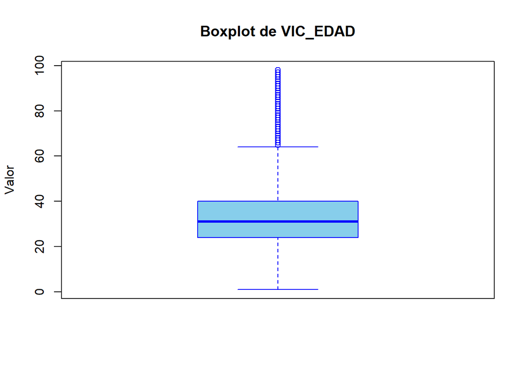

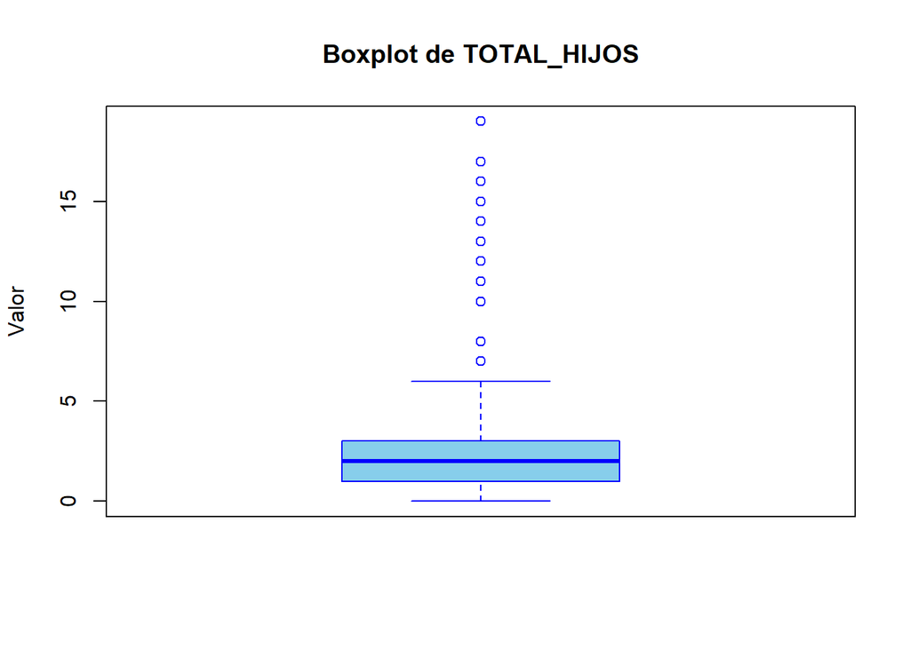

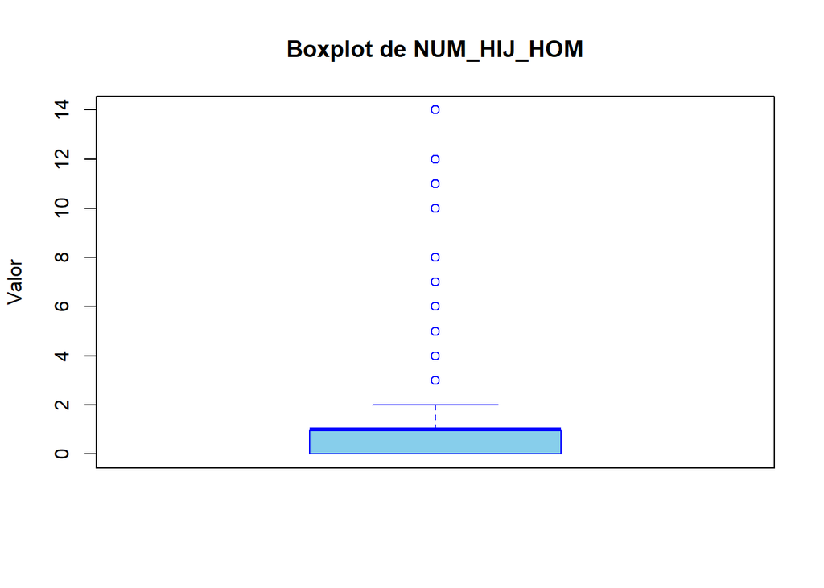

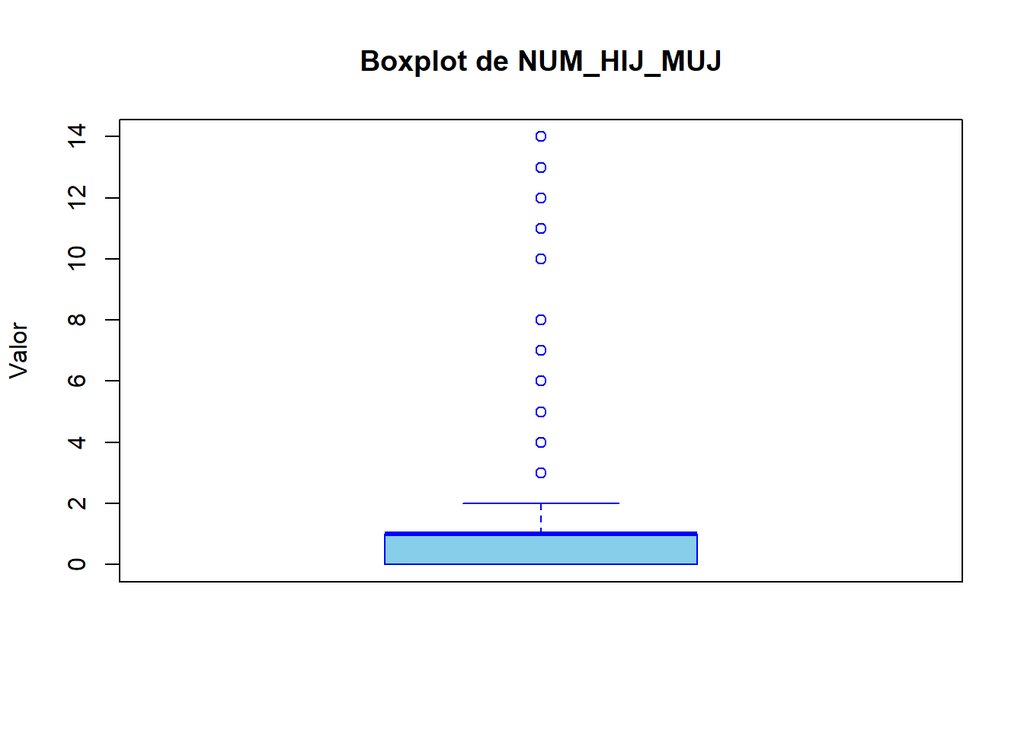

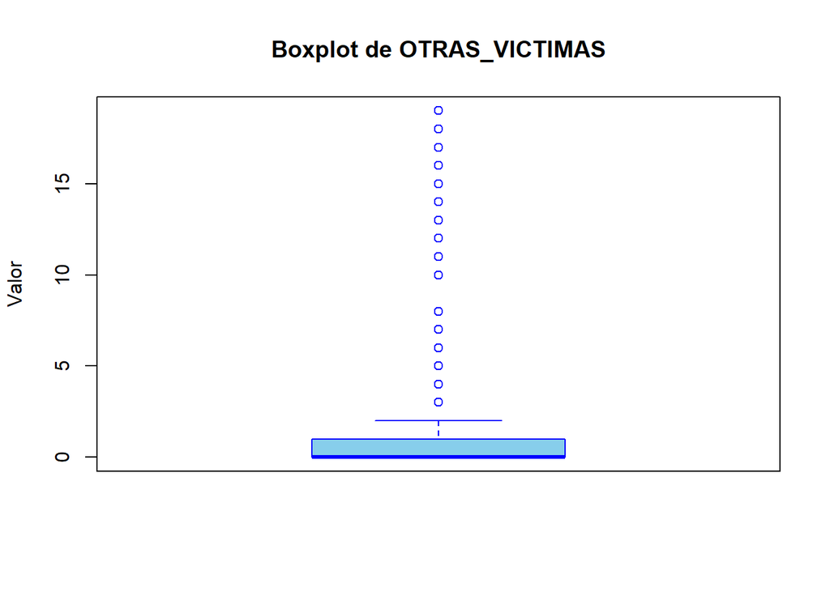

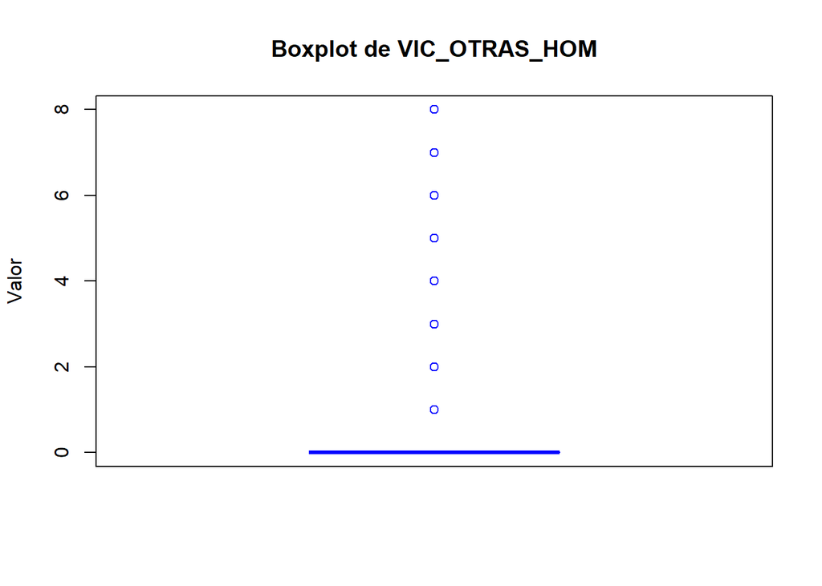

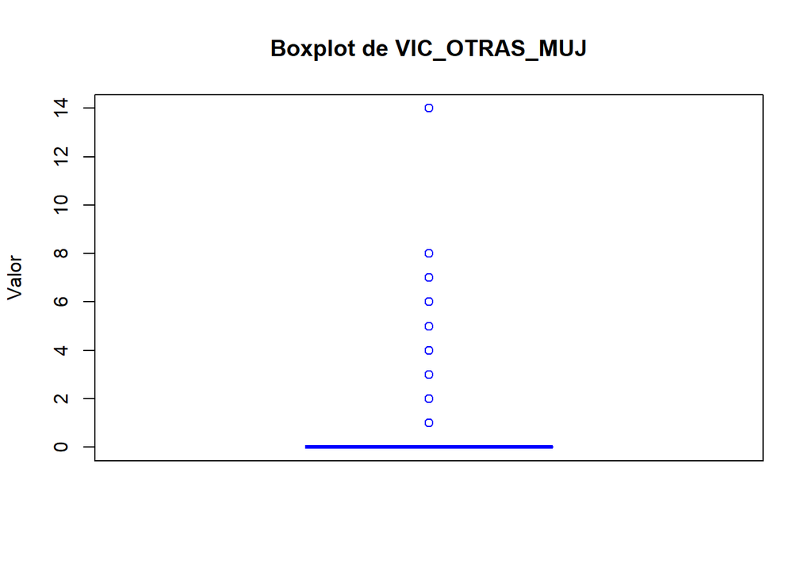

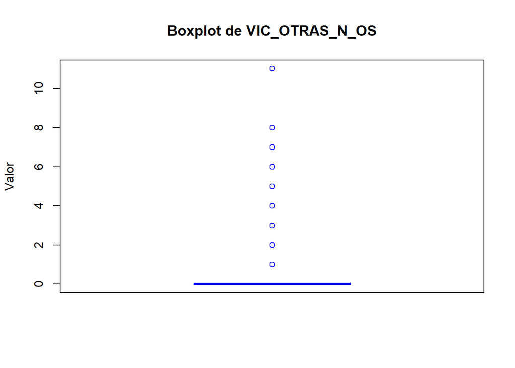

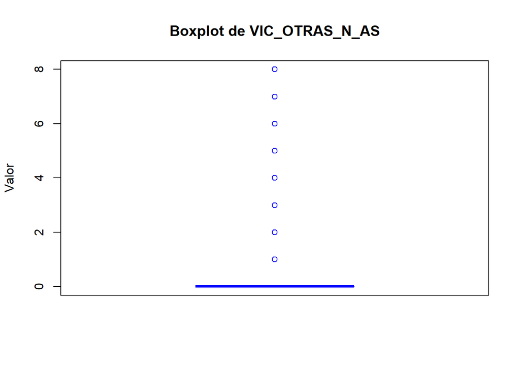

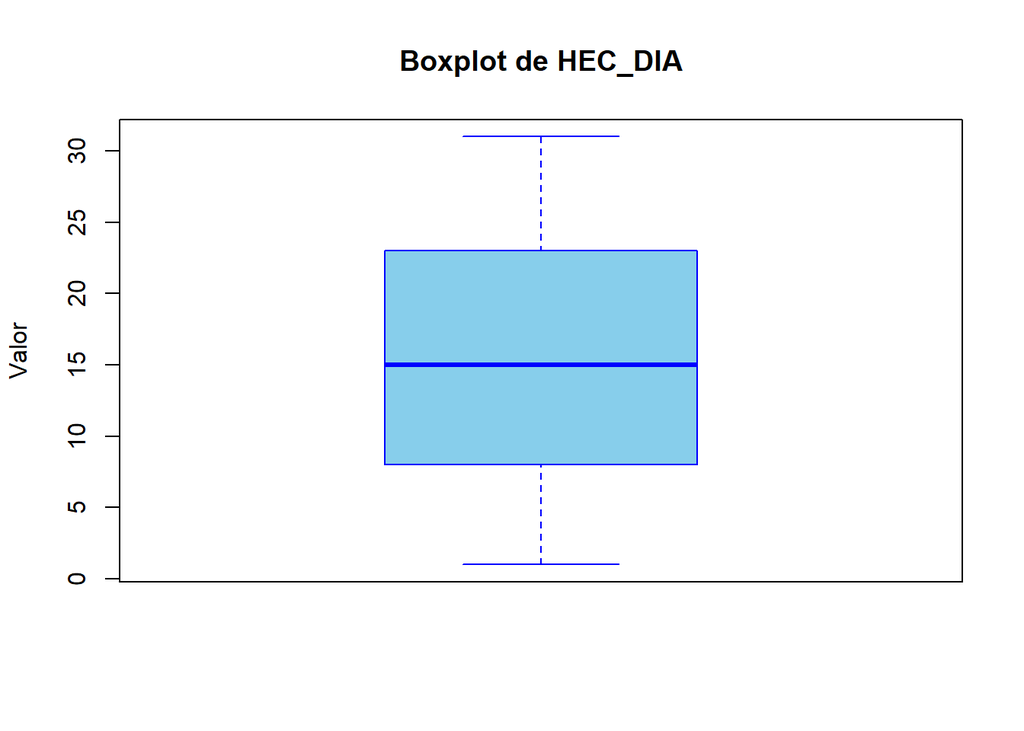

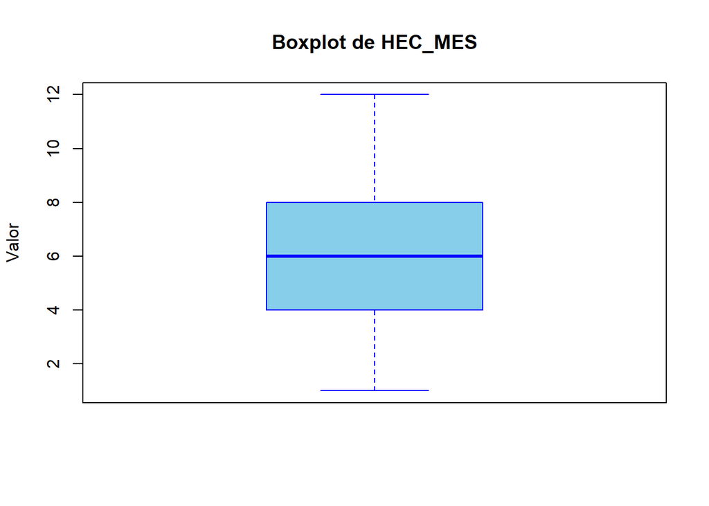

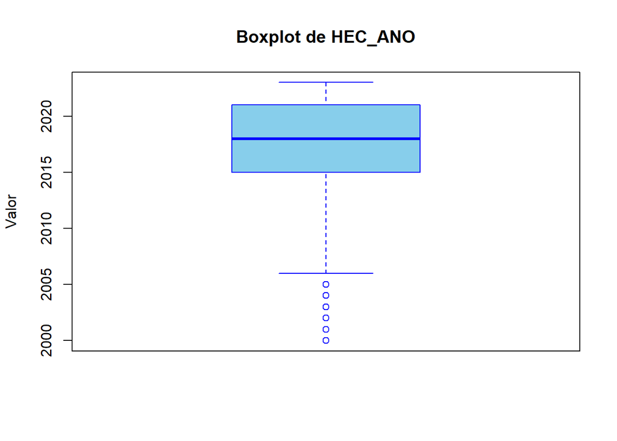

[5 more figures not shown]

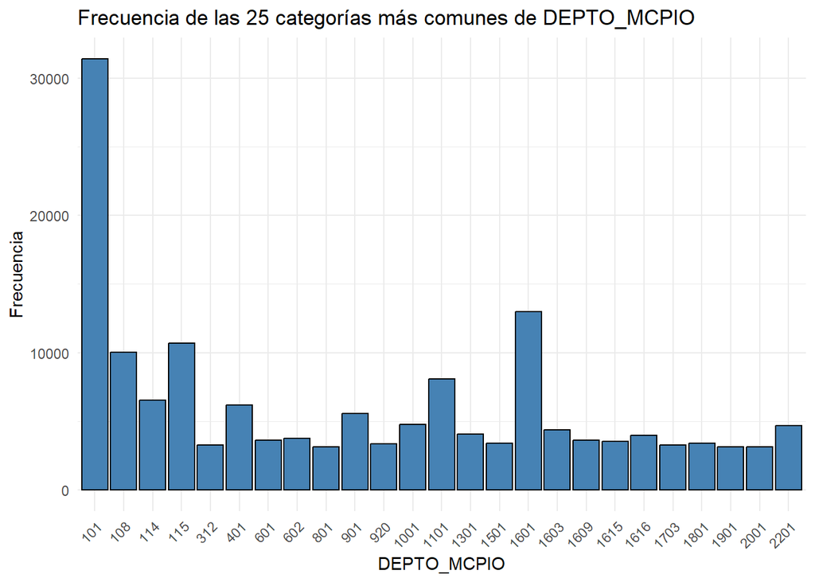

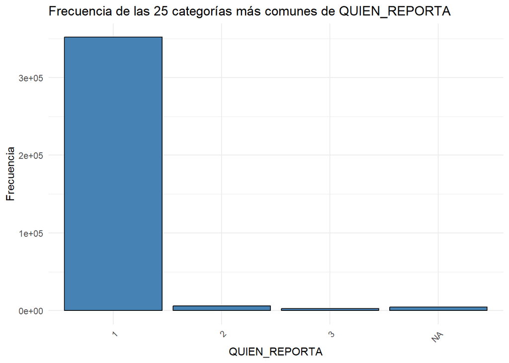

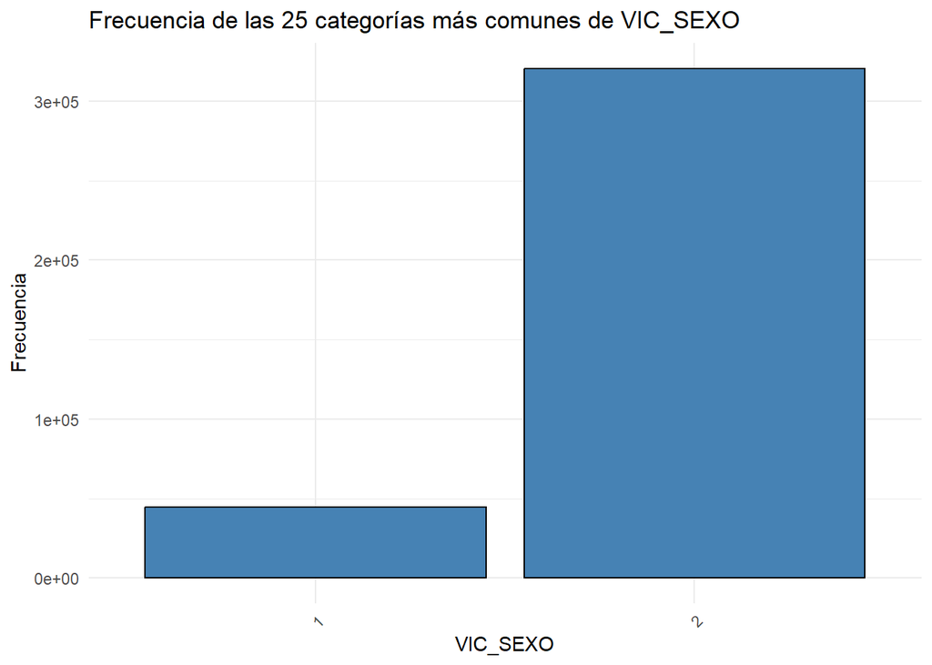

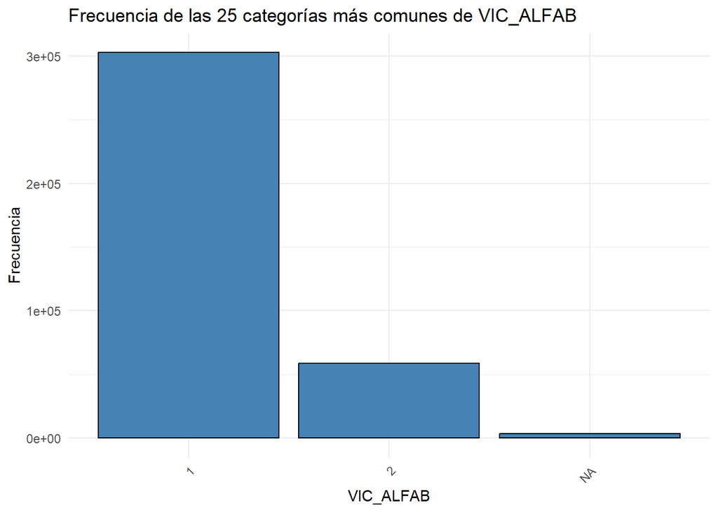

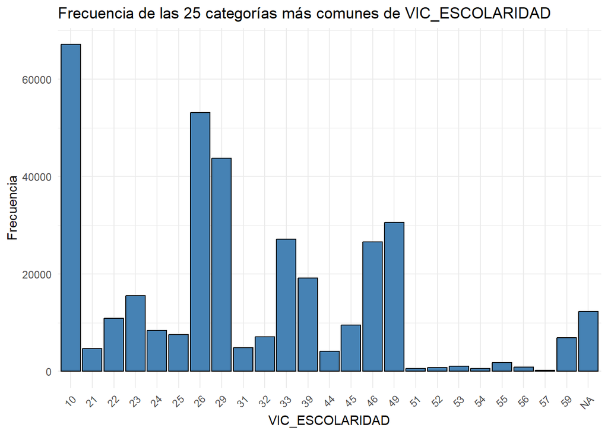

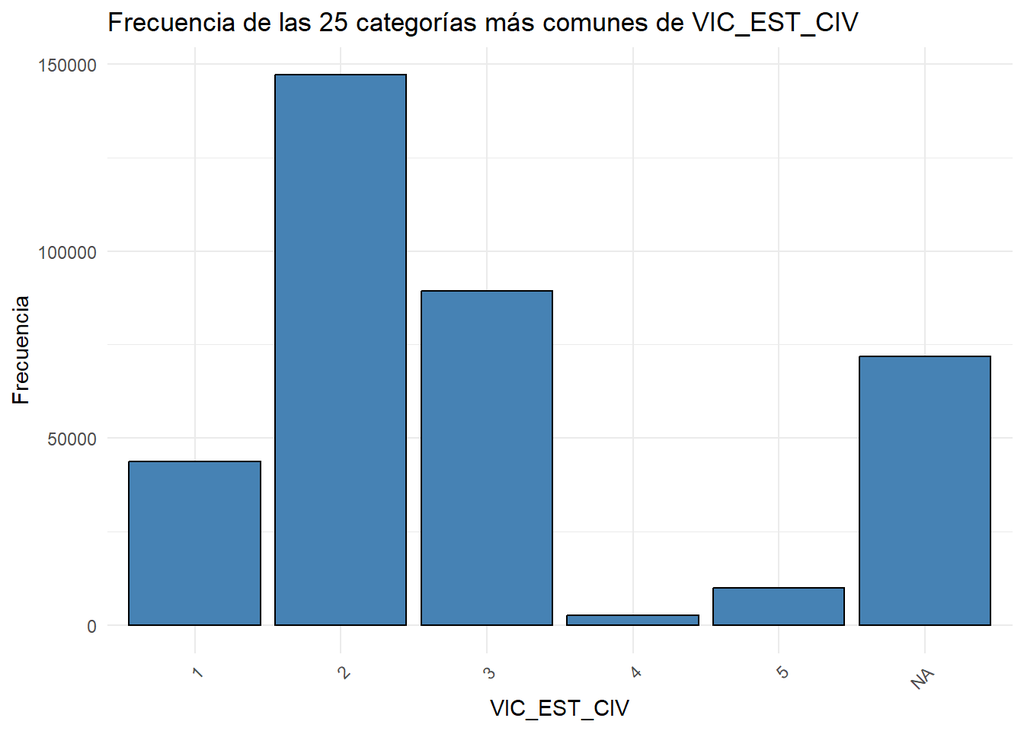

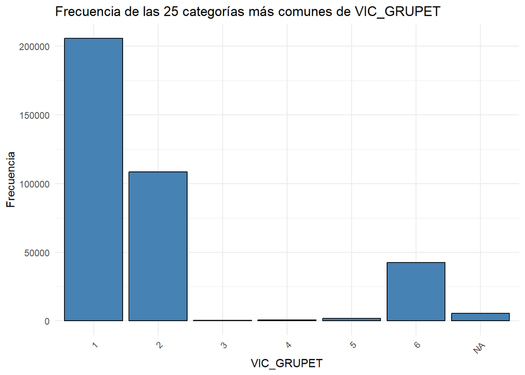

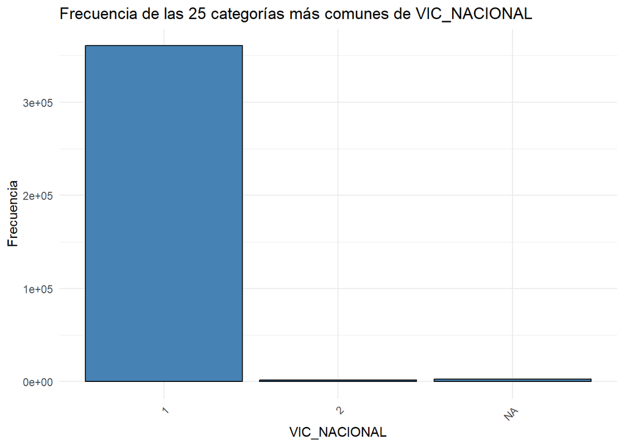

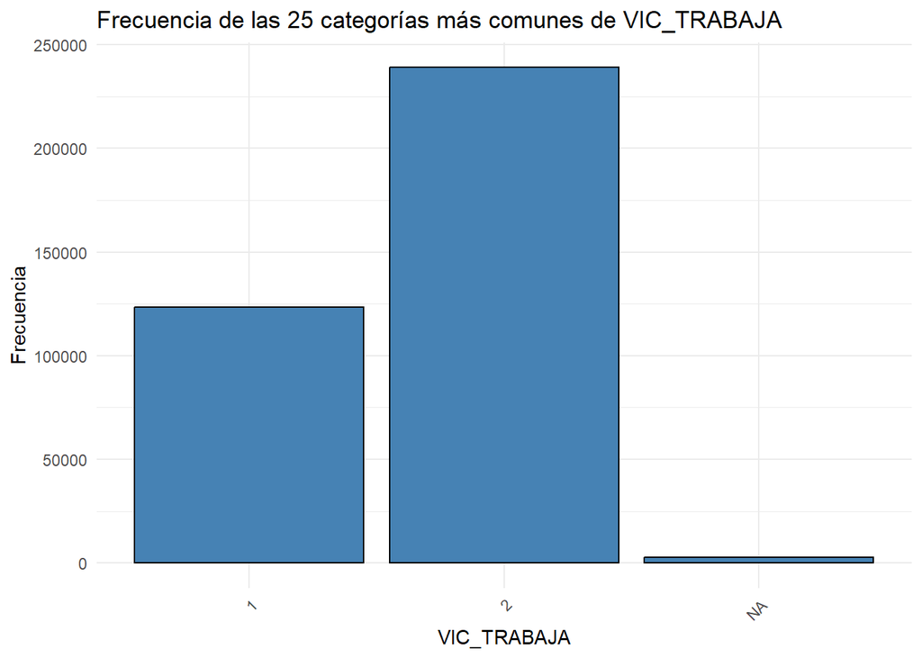

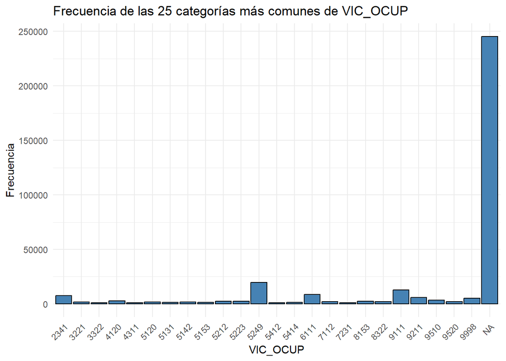

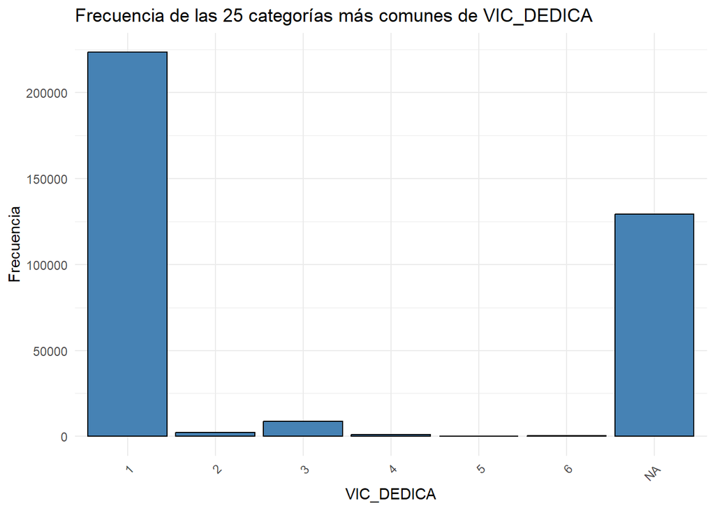

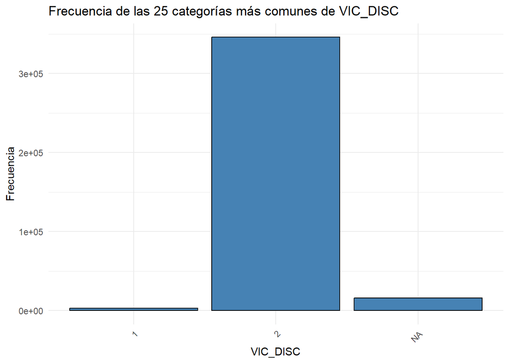

[19 more figures not shown]

Para la relación entre variables se puso énfasis en la evolución temporal, diferencias por sexo, edad y tipo de violencia. Esto con el fin de detectar comportamientos recurrentes y posibles tendencias que merecen atención desde una perspectiva preventiva.

## Relaciones temporales

### Evolución anual de denuncias

Se busca analizar cómo ha cambiado el número de denuncias por año, para determinar tendencias a lo largo del tiempo.

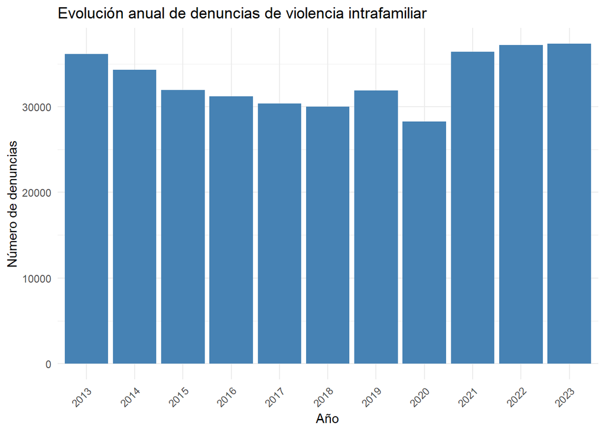

### Estacionalidad

Se analiza si existen patrones mensuales que indiquen repuntes en determinadas épocas del año.

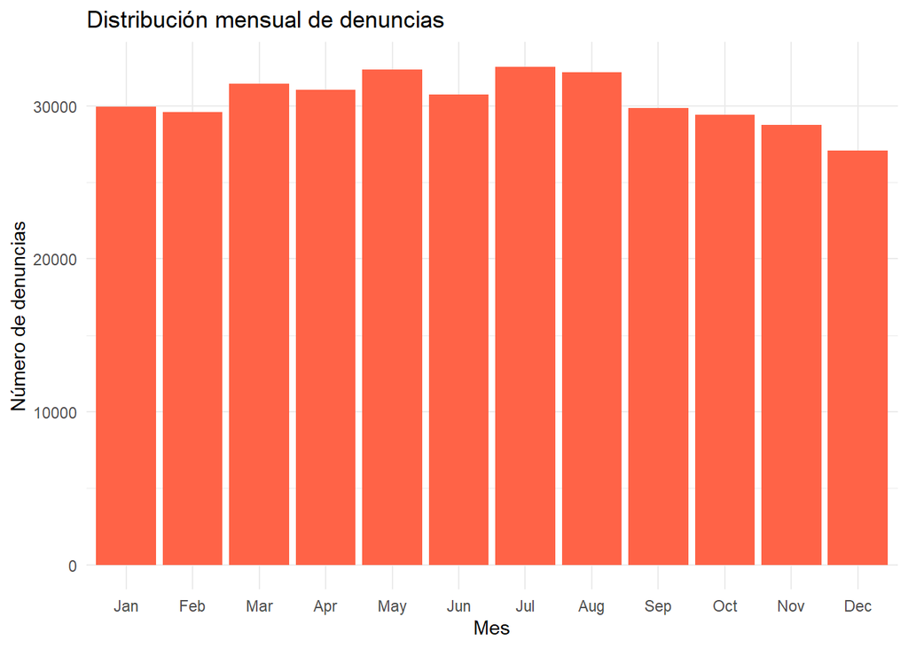

### Evolucion temporal

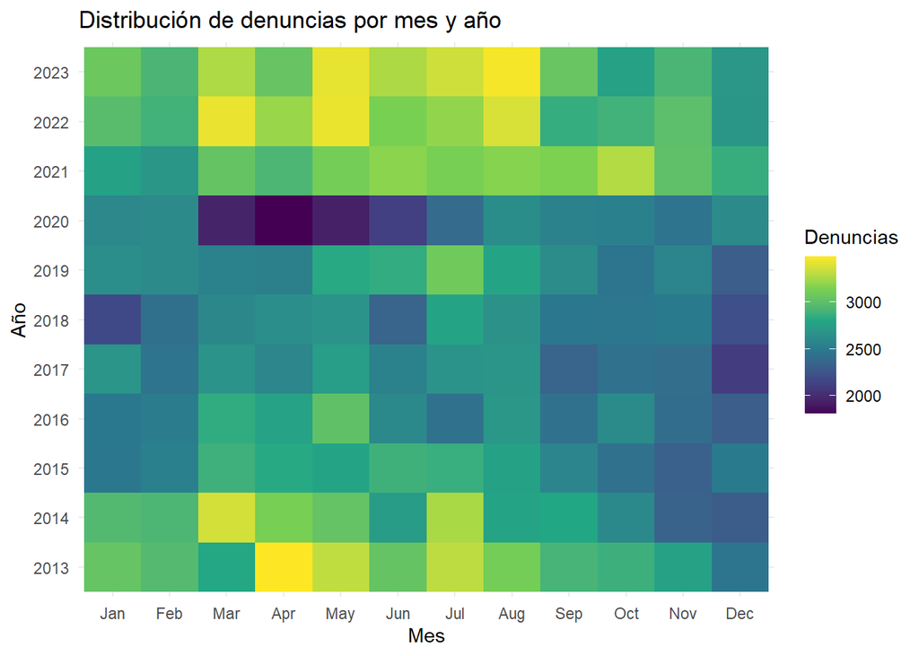

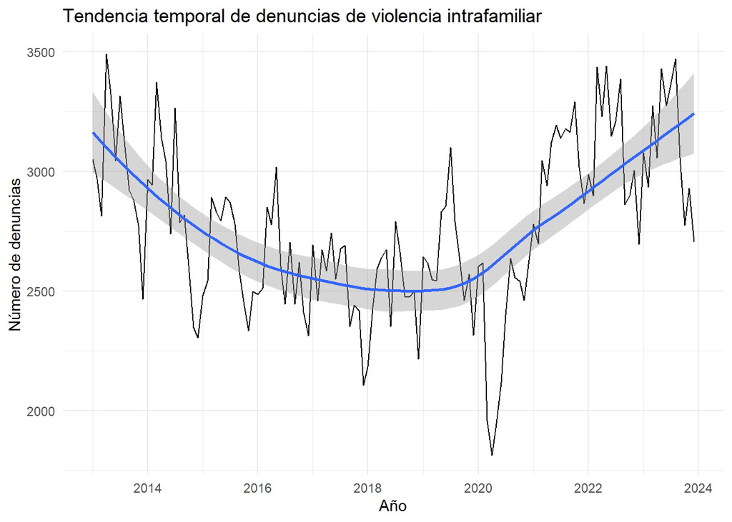

Para observar la evolución de denuncias por mes y año se realizarón gráficos de tendencia y distribución para detallar más la información sobre denuncias en relación al tiempo.

En el gráfico de distribución de denuncia por mes y año se observa el año 2013 con tuvo varias denuncias, siendo los meses abril, mayo y julio los que mayor cantidad de denuncias tuvieron, con 3500 aproximadamente. A partir de 2014, la cantidad disminuye paulatinamente, con un único pico de 3500 denuncias en el mes de marzo de 2014. Para 2020 la cantidad de denuncias disminuyó de forma abrupta del mes de febrero a abril, por temas de pandemia. Esto se podría explicar debido al cierre de algunas instituciones y toque de queda. Sin embargo como ya se ha explicado, los casos vuelven a subir a partir de 2021.

El gráfico de tendencia temporal de denuncias describe los mismos comportamientos anteriormente planteados. Indicando con la linea azul la tendencia y dirección general de cambio a tráves de los años 2013 a 2023 suavizando las fluctuaciones. Mientras que la línea negra nos explica el cambio real de las denuncias a través del tiempo.

## Relaciones demográficas

### Relación entre sexo de víctima y agresor

Se examina la composición de las denuncias según el sexo de la víctima y del agresor.

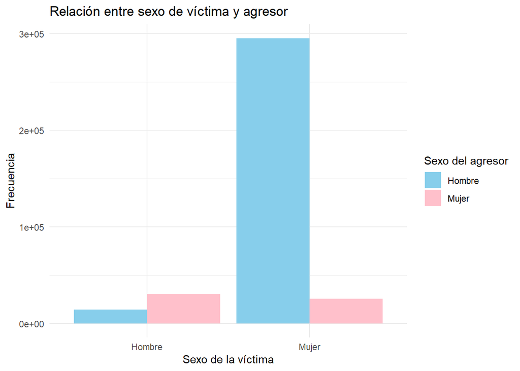

```
##
##          1      2
##   1  14206  30192
##   2 295475  25256
```

```
##
##              1          2
##   1 0.31996937 0.68003063
##   2 0.92125488 0.07874512
```

```
##
##  Pearson's Chi-squared test with Yates' continuity correction
##
## data:  tabla_sexo
## X-squared = 109470, df = 1, p-value < 2.2e-16
```

### Distribución por edad

Se observa cómo varía la incidencia de violencia según los rangos etarios, tanto en víctimas como en agresores. Esto permite identificar grupos especialmente vulnerables o recurrentes.

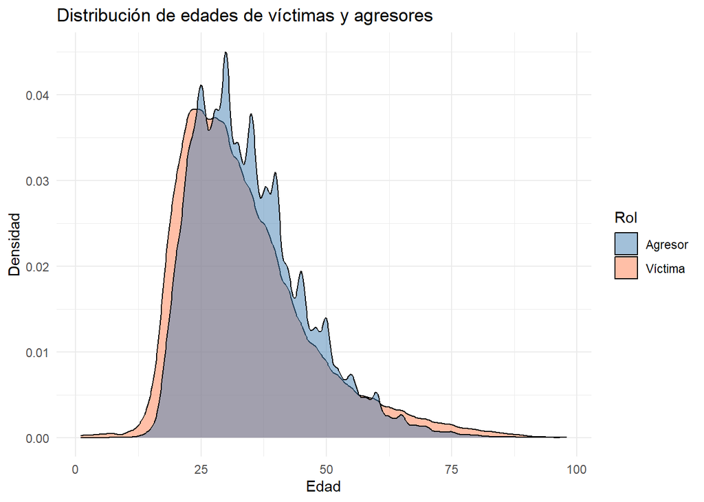

```
##
##  Spearman's rank correlation rho
##
## data:  original$VIC_EDAD and original$AGR_EDAD
## S = 3.1008e+15, p-value < 2.2e-16
## alternative hypothesis: true rho is not equal to 0
## sample estimates:
##      rho
## 0.516148
```

En el gráfico de la distribución de edades de víctimas y agresores, donde los datos de los agresores tienen un color azul, y el de las víctimas un color naranja; Se observa que tanto víctimas como agresores tienden a concentrarse en edades más jóvenes, de entre 13 a 38 años, con un pico alrededor de los 25 años. También se puede observar que a medida que la edad aumenta, la densidad disminuye gradualmente hasta llegar a los agresores de edades cercanas a los 100 años.

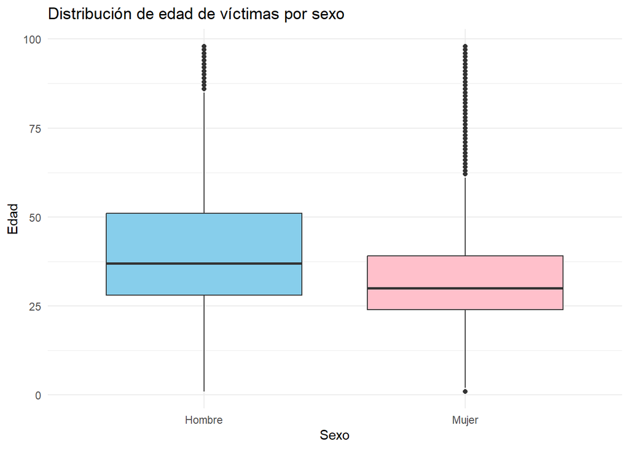

Con el Boxplot de Distribución de edad de víctima por sexo, nos indican que la mediana de las víctimas mujeres es ligeramente inferior a la de los hombres, siendo de aproximadamente 30 años mediana de edad en mujeres. Además, el IQR de las mujeres es más estrecho que el de los hombres, lo que quiere decir que las edades de las víctimas mujeres se concentran más alrededor de la mediana. En el caso de las víctimas hombres, la mediana se concentra alrededor de los 38 años.

Para los valores atípicos, se observa que en el caso de las víctimas mujeres existe una mayor variabilidad en las edades extremas del grupo.

## Relaciones socioeconómicas

### Educación y violencia

Se explora la relación entre el nivel educativo y la incidencia de violencia, en busca de posibles factores asociados al acceso a la educación.

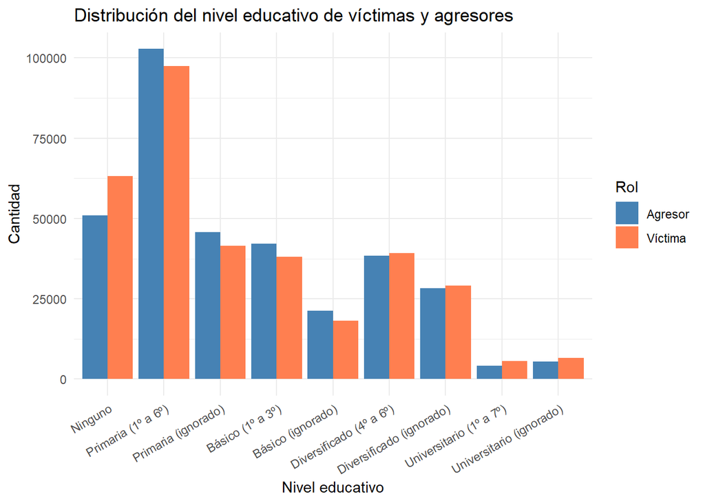

### Situación laboral

Se analiza si la situación laboral tiene alguna relación con los casos reportados, evaluando si existen condiciones económicas que podrían influir en el riesgo o en la denuncia.

```
##          VIC_TRABAJA        AGR_TRABAJA      n porcentaje
## 1    Víctima trabaja    Agresor trabaja  85790       24.6
## 2    Víctima trabaja Agresor No trabaja  33109        9.5
## 3 Víctima No trabaja    Agresor trabaja 191055       54.8
## 4 Víctima No trabaja Agresor No trabaja  38541       11.1
```

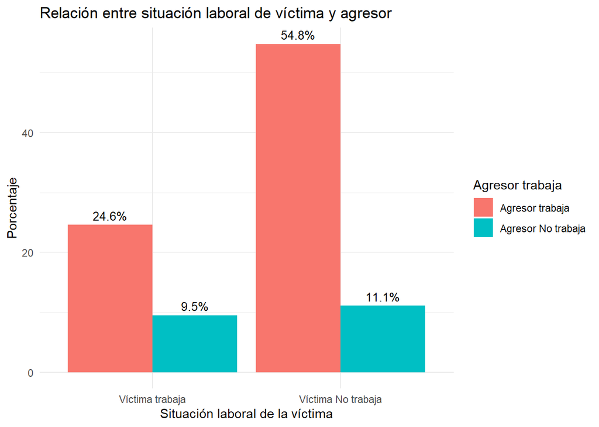

Con base a la tabla y el gráfico, podemos notar que para una víctima que trabaja, el 24.6% de los casos involucran a un agresor que trabaja, mientras que el 9.5% involucran a un agresor que no trabaja. Mientras que en los caos donde la víctima no trabaja: El 54.8% de los casos involucran a un agresor que trabaja, mientras que el 11.1% involucran a un agresor que no trabaja.

Estos datos revelan que la mayoría de los casos de violencia, independientemente de la situación laboral de la víctima, involucran a agresores que trabajan. Sin embargo, la proporción es significativamente mayor cuando la víctima no trabaja, con un 54.8%. Esto sugiere que la situación laboral de la víctima podría ser un factor relevante en la dinámica de la violencia, con una mayor vulnerabilidad cuando la víctima no tiene un empleo.

### Estado civil

Se estudia cómo varía la violencia según el estado civil, identificando si existen diferencias importantes entre personas casadas, solteras, divorciadas o en unión libre.

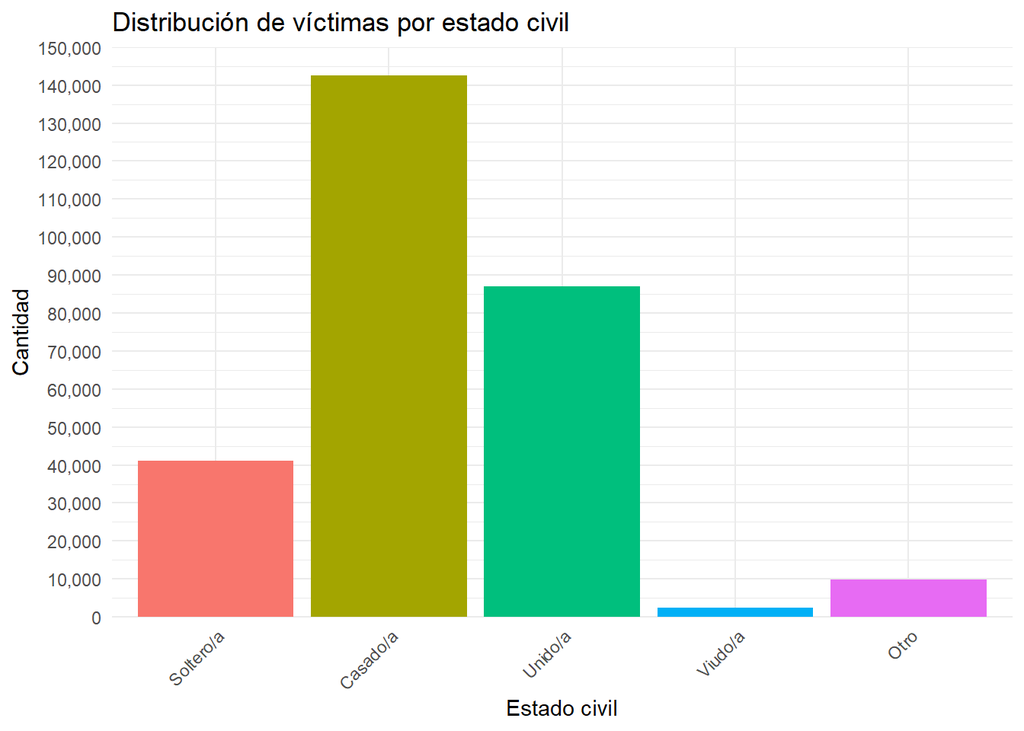

Este gráfico de barras muestra la distribución de la cantidad de víctimas de violencia según su estado civil. Se observa que la mayoría de las víctimas se encuentran en relaciones de pareja estables, ya sea matrimonio o unión libre, con una cantidad significativamente mayor en el estado civil Casado/a. La cantidad de víctimas solteras es notablemente menor, y la incidencia en viudos/as y en la categoría “Otro” es muy baja. Por lo que las relaciones de pareja pueden ser un factor de riesgo importante en la violencia, y que la violencia es más prevalente en contextos de relaciones a largo plazo.

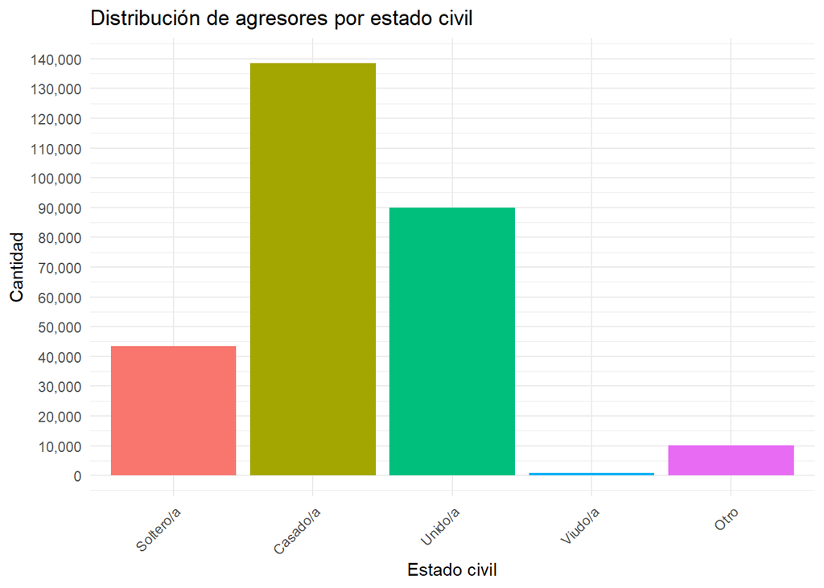

Este gráfico de barras muestra la distribución de la cantidad de agresores según su estado civil. Similar al gráfico de víctimas, se observa que la mayoría de los agresores se encuentran en relaciones de pareja estables. De igual manera, la cantidad de agresores solteros es notablemente menor, y la incidencia en viudos/as y en la categoría “Otro” es muy baja.

## Relaciones geográficas

### Distribución por departamento

Se visualiza cómo se distribuyen los casos a lo largo del territorio nacional, detectando departamentos con mayor o menor prevalencia.

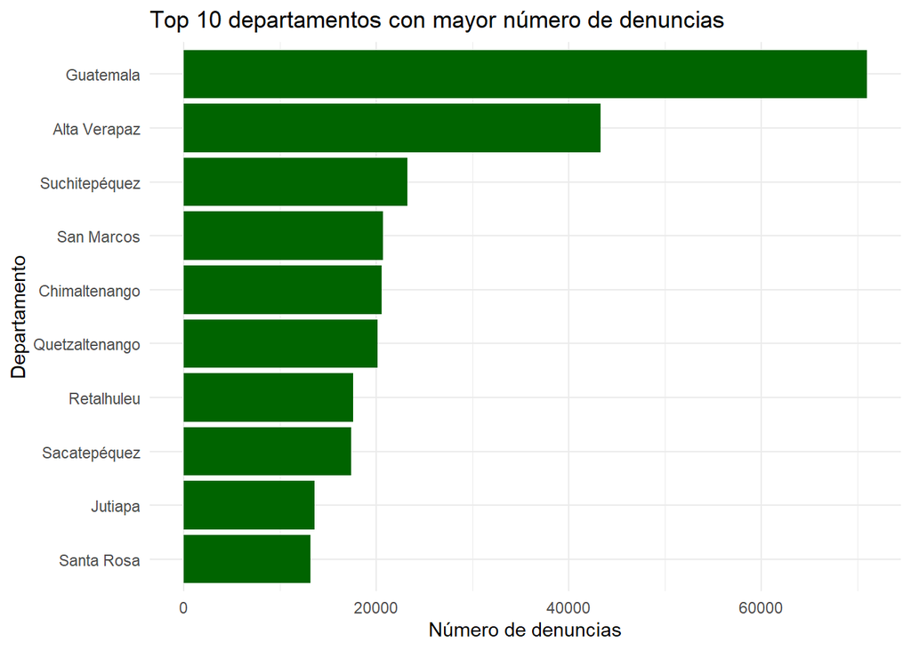

Se observa que el departamento de Guatemala tiene el número más alto de denuncias, seguido de Alta Verapaz y Suchitepéquez. Los departamentos de San Marcos, Chimaltenango y Quetzaltenango tienen un número similar de denuncias, mientras que Retalhuleu, Sacatepéquez, Jutiapa y Santa Rosa tienen el menor número de denuncias entre los 10 departamentos principales.

### Diferencias urbano-rural

Se contrasta la violencia reportada en zonas urbanas y rurales, permitiendo analizar cómo el entorno territorial puede influir en la incidencia o visibilización de los casos.

```
##
##   Urbana    Rural
## 57.38654 42.61346
```

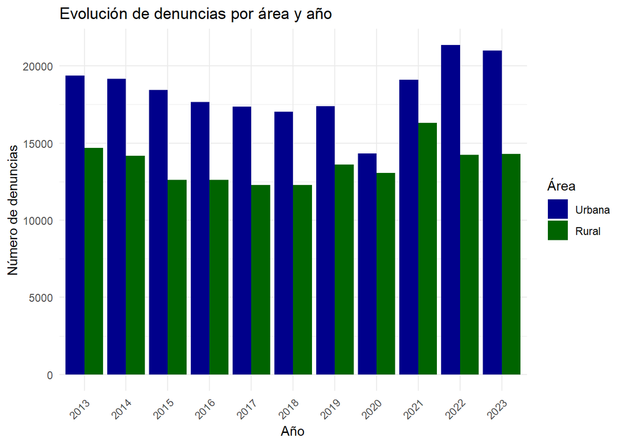

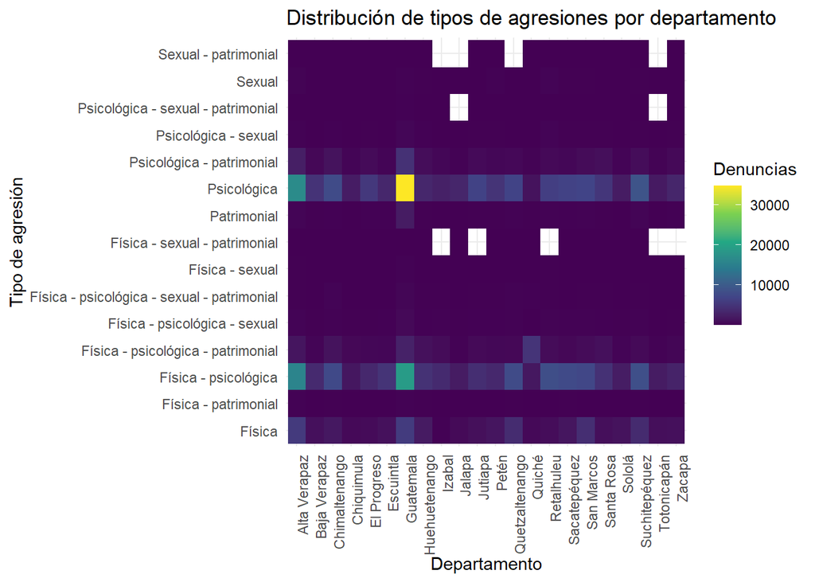

Para el gráfico de denuncias por área y año se observa que tanto en áreas urbanas como rurales, el número de denuncias ha fluctuado a lo largo de los años, con un incremento notable a partir de 2020. En general, las áreas urbanas tienden a tener un mayor número de denuncias en comparación con las áreas rurales, aunque la diferencia no es constante. Este gráfico permite visualizar la tendencia temporal de las denuncias y comparar la incidencia entre áreas urbanas y rurales.